# p8131_stl2137_hw3

# Problem 1

## Part 1

```r
### Data import and wrangling following class code
# Exposed = high alc, unexposed = low alc
case_expo = c(1, 4, 25, 42, 19, 5)
cont_expo = c(9, 26, 29, 27, 18, 0)
case_unexp = c(0, 5, 21, 34, 36, 8)
cont_unexp = c(106, 164, 138, 139, 88, 31)
cbind(case_expo, case_unexp, cont_expo, cont_unexp)
```

```
##      case_expo case_unexp cont_expo cont_unexp
## [1,]         1          0         9        106
## [2,]         4          5        26        164
## [3,]        25         21        29        138
## [4,]        42         34        27        139
## [5,]        19         36        18         88
## [6,]         5          8         0         31
```

```r
age = c(25, 35, 45, 55, 65, 75, 25, 35, 45, 55, 65, 75)

# Cases = 1, Controls = 0
x = c(1, 1, 1, 1, 1, 1, 0, 0, 0, 0, 0, 0)
y = cbind(c(case_expo, case_unexp), c(cont_expo, cont_unexp))
```

```r
### Fiting model
logit_alc = glm(y ~ x + age, family=binomial(link='logit'))
summary(logit_alc)
```

```
##
## Call:
## glm(formula = y ~ x + age, family = binomial(link = "logit"))
##
## Deviance Residuals:
##      Min        1Q    Median        3Q       Max
## -2.59974  -1.72957   0.06822   1.19015   1.50808
##
## Coefficients:
##              Estimate Std. Error z value Pr(>|z|)
## (Intercept) -5.023449   0.418224 -12.011   <2e-16 ***
## x            1.780000   0.187086   9.514   <2e-16 ***
## age          0.061579   0.007291   8.446   <2e-16 ***
## ---
## Signif. codes:  0 '***' 0.001 '**' 0.01 '*' 0.05 '.' 0.1 ' ' 1
##
## (Dispersion parameter for binomial family taken to be 1)
##
##     Null deviance: 211.608  on 11  degrees of freedom
## Residual deviance:  31.932  on  9  degrees of freedom
## AIC: 78.259
##
## Number of Fisher Scoring iterations: 4
```

The log odds of developing esophaegeal cancer is -5.023449 given the low alcohol consumption group.

The log odds ratio of developing esophaegeal cancer, holding age constant, is 1.78 when comparing the high alcohol consumption group to the low alcohol consumption group.

The log odds ratio of age is 0.061579 for every 1 year increase, holding all other variables constant.

# Problem 2

```r
### Importing Data
### species_type: 75 = 1, 73 = 0; root_type: bean = 1, cucumber = 0
orobanche_75_bean <- tibble(
  success = c(10, 23, 23, 26, 17),
  total = c(39, 62, 81, 51, 39)
) %>%
  mutate(
    species_type = c(1, 1, 1, 1, 1),
    root_type = c(1, 1, 1, 1, 1)
  )

orobanche_75_cucumber <- tibble(
  success = c(5, 53, 55, 32, 46, 10),
  total = c(6, 74, 72, 51, 79, 13)
) %>%
  mutate(
    species_type = c(1, 1, 1, 1, 1, 1),
    root_type = c(0, 0, 0, 0, 0, 0)
  )

orobanche_73_bean <- tibble(
  success = c(8, 10, 8, 23, 0),
  total = c(16, 30, 28, 45, 4)
) %>%
  mutate(
    species_type = c(0, 0, 0, 0, 0),
    root_type = c(1, 1, 1, 1, 1)
  )

orobanche_73_cucumber <- tibble(
  success = c(3, 22, 15, 32, 3),
  total = c(12, 41, 30, 51, 7)
) %>%
  mutate(
    species_type = c(0, 0, 0, 0, 0),
    root_type = c(0, 0, 0, 0, 0)
  )

plant_dat <- bind_rows(orobanche_75_bean, orobanche_73_bean,orobanche_75_cucumber, orobanche_73_cucumber)
```

## Part 1

1. Fit a logistic regression model to study the relation between germination rates and different types of seed and root extract. Interpret the result.

```r
### Creating a suitable y variable to glm
rates <- cbind(plant_dat$success, plant_dat$total - plant_dat$success)

### Fitting Logistic model
logit_plant = glm(rates ~ species_type + root_type, family = binomial(link = 'logit'), data = plant_dat)

summary(logit_plant)
```

```
##
## Call:
## glm(formula = rates ~ species_type + root_type, family = binomial(link = "logit"),
##     data = plant_dat)
##
## Deviance Residuals:
##     Min       1Q   Median       3Q      Max
## -2.3919  -0.9949  -0.3744   0.9831   2.4766
##
## Coefficients:
##              Estimate Std. Error z value Pr(>|z|)
## (Intercept)    0.3643     0.1428   2.550   0.0108 *
## species_type   0.2705     0.1547   1.748   0.0804 .
## root_type     -1.0647     0.1442  -7.383 1.55e-13 ***
## ---
## Signif. codes:  0 '***' 0.001 '**' 0.01 '*' 0.05 '.' 0.1 ' ' 1
##
## (Dispersion parameter for binomial family taken to be 1)
##
##     Null deviance: 98.719  on 20  degrees of freedom
## Residual deviance: 39.686  on 18  degrees of freedom
## AIC: 122.28
##
## Number of Fisher Scoring iterations: 4
```

The log odds of germination is 0.3642 given the cucumber root extract media and Orobanche 73 are used.

`species_type` is an insignificant variable when $\alpha = 0.05$ with a p-value of 0.0804. The log odds ratio of germination is 0.2705 when comparing Orobanche 75 to Orobanche 73.

The log odds ratio of germination is -1.0647 when comparing bean root extract media to cucumber root extract media, holding all other variables constant.

## Part 2

```r
### goodness of fit
pval= 1 - pchisq(logit_plant$deviance, 21-3)
pval
```

```
## [1] 0.00230277
```

Since the p-value is < 0.05, we reject the null hypothesis and conclude that the model is a bad fit.

```r
# Calculate Overdispersion parameter
G.stat = sum(residuals(logit_plant,type='pearson')^2) # pearson chisq
G.stat
```

```
## [1] 38.31062
```

```r
phi = G.stat/(21-3)
phi
```

```
## [1] 2.128368
```

```r
tilde.phi = logit_plant$deviance/logit_plant$df.residual
tilde.phi
```

```
## [1] 2.204772
```

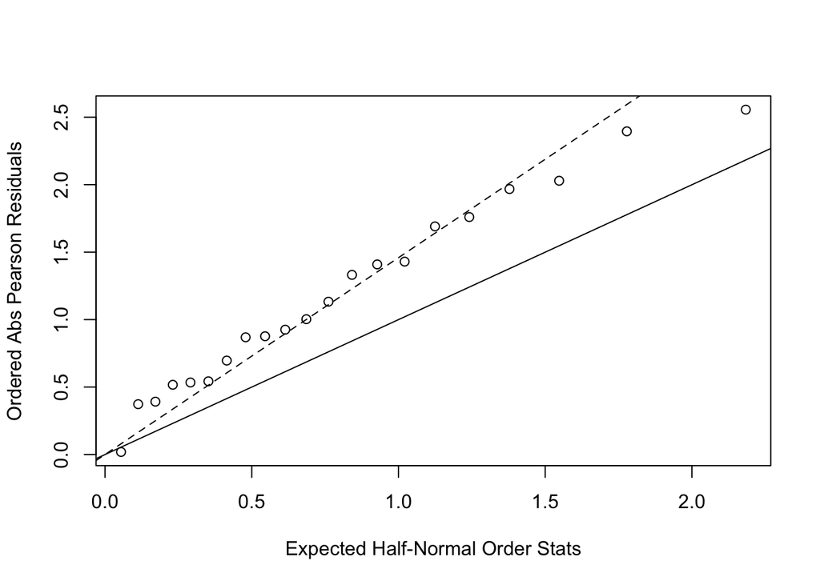

```r
res = residuals(logit_plant, type='pearson')
plot(qnorm((21+1:21+0.5)/(2*21+1.125)),sort(abs(res)),xlab='Expected Half-Normal Order Stats',ylab='Ordered Abs Pearson Residuals')
abline(a=0,b=1)
abline(a=0,b=sqrt(phi),lty=2)
```

From the plot, we can also visually confirm there is overdispersion.

```r
### fit model with constant over-dispersion
summary(logit_plant, dispersion = phi)
```

```
##
## Call:
## glm(formula = rates ~ species_type + root_type, family = binomial(link = "logit"),
##     data = plant_dat)
##
## Deviance Residuals:
##     Min       1Q   Median       3Q      Max
## -2.3919  -0.9949  -0.3744   0.9831   2.4766
##
## Coefficients:
##              Estimate Std. Error z value Pr(>|z|)
## (Intercept)    0.3643     0.2084   1.748   0.0804 .
## species_type   0.2705     0.2257   1.198   0.2308
## root_type     -1.0647     0.2104  -5.061 4.18e-07 ***
## ---
## Signif. codes:  0 '***' 0.001 '**' 0.01 '*' 0.05 '.' 0.1 ' ' 1
##
## (Dispersion parameter for binomial family taken to be 2.128368)
##
##     Null deviance: 98.719  on 20  degrees of freedom
## Residual deviance: 39.686  on 18  degrees of freedom
## AIC: 122.28
##
## Number of Fisher Scoring iterations: 4
```

## Part 3

A plausible cause of over dispersion is that there is correlation between the germination of the two species of Orobanche seeds and the root media.